# Red Wine Quality Exploration by Cora Ou

This report explores a dataset containing 12 attributes for approximately 1600 red wines.

# Univariate Plots Section

```
## 'data.frame':    1599 obs. of  13 variables:
##  $ X                   : int  1 2 3 4 5 6 7 8 9 10 ...
##  $ fixed.acidity       : num  7.4 7.8 7.8 11.2 7.4 7.4 7.9 7.3 7.8 7.5 ...
##  $ volatile.acidity    : num  0.7 0.88 0.76 0.28 0.7 0.66 0.6 0.65 0.58 0.5 ...
##  $ citric.acid         : num  0 0 0.04 0.56 0 0 0.06 0 0.02 0.36 ...
##  $ residual.sugar      : num  1.9 2.6 2.3 1.9 1.9 1.8 1.6 1.2 2 6.1 ...
##  $ chlorides           : num  0.076 0.098 0.092 0.075 0.076 0.075 0.069 0.065 0.073 0.071 ...
##  $ free.sulfur.dioxide : num  11 25 15 17 11 13 15 15 9 17 ...
##  $ total.sulfur.dioxide: num  34 67 54 60 34 40 59 21 18 102 ...
##  $ density             : num  0.998 0.997 0.997 0.998 0.998 ...
##  $ pH                  : num  3.51 3.2 3.26 3.16 3.51 3.51 3.3 3.39 3.36 3.35 ...
##  $ sulphates           : num  0.56 0.68 0.65 0.58 0.56 0.56 0.46 0.47 0.57 0.8 ...
##  $ alcohol             : num  9.4 9.8 9.8 9.8 9.4 9.4 9.4 10 9.5 10.5 ...
##  $ quality             : int  5 5 5 6 5 5 5 7 7 5 ...
```

```
##        X          fixed.acidity   volatile.acidity  citric.acid
##  Min.   :   1.0   Min.   : 4.60   Min.   :0.1200   Min.   :0.000
##  1st Qu.: 400.5   1st Qu.: 7.10   1st Qu.:0.3900   1st Qu.:0.090
##  Median : 800.0   Median : 7.90   Median :0.5200   Median :0.260
##  Mean   : 800.0   Mean   : 8.32   Mean   :0.5278   Mean   :0.271
##  3rd Qu.:1199.5   3rd Qu.: 9.20   3rd Qu.:0.6400   3rd Qu.:0.420
##  Max.   :1599.0   Max.   :15.90   Max.   :1.5800   Max.   :1.000
##  residual.sugar     chlorides       free.sulfur.dioxide
##  Min.   : 0.900   Min.   :0.01200   Min.   : 1.00
##  1st Qu.: 1.900   1st Qu.:0.07000   1st Qu.: 7.00
##  Median : 2.200   Median :0.07900   Median :14.00
##  Mean   : 2.539   Mean   :0.08747   Mean   :15.87
##  3rd Qu.: 2.600   3rd Qu.:0.09000   3rd Qu.:21.00
##  Max.   :15.500   Max.   :0.61100   Max.   :72.00
##  total.sulfur.dioxide    density             pH          sulphates
##  Min.   :  6.00       Min.   :0.9901   Min.   :2.740   Min.   :0.3300
##  1st Qu.: 22.00       1st Qu.:0.9956   1st Qu.:3.210   1st Qu.:0.5500
##  Median : 38.00       Median :0.9968   Median :3.310   Median :0.6200
##  Mean   : 46.47       Mean   :0.9967   Mean   :3.311   Mean   :0.6581
##  3rd Qu.: 62.00       3rd Qu.:0.9978   3rd Qu.:3.400   3rd Qu.:0.7300
##  Max.   :289.00       Max.   :1.0037   Max.   :4.010   Max.   :2.0000
##     alcohol         quality
##  Min.   : 8.40   Min.   :3.000
##  1st Qu.: 9.50   1st Qu.:5.000
##  Median :10.20   Median :6.000
##  Mean   :10.42   Mean   :5.636
##  3rd Qu.:11.10   3rd Qu.:6.000
##  Max.   :14.90   Max.   :8.000
```

our data set contains 12 variables (13 in total, but variable x does not count) and 1599 observations. Let’s first plot histogram of quality.

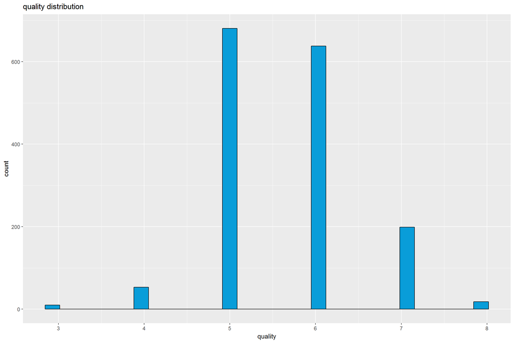

The data of the quality are discrete. Most of them fall on 5 and 6. I wonder how other variables besides chemical properties like alcohol,residual sugar, PH, density, acidity and acid, SO2(free and total) and sulphates and chlorides affect quality, and how they link to each other.

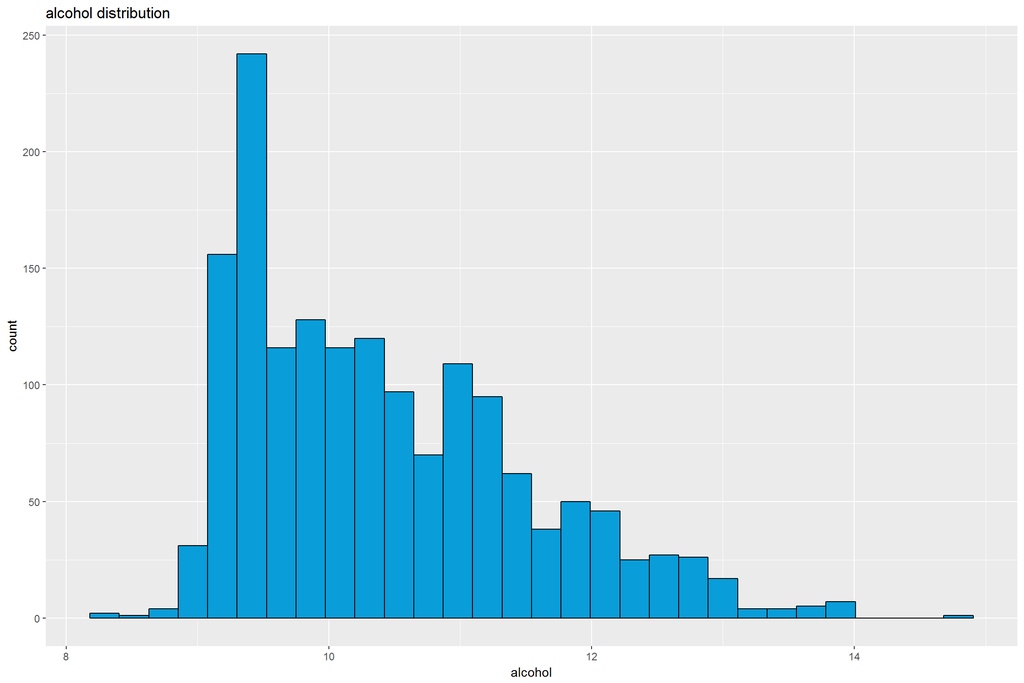

```
##    Min. 1st Qu.  Median    Mean 3rd Qu.    Max.
##    8.40    9.50   10.20   10.42   11.10   14.90
```

Alcohol peaks around 9, with its median 10.20 and mean 10.42

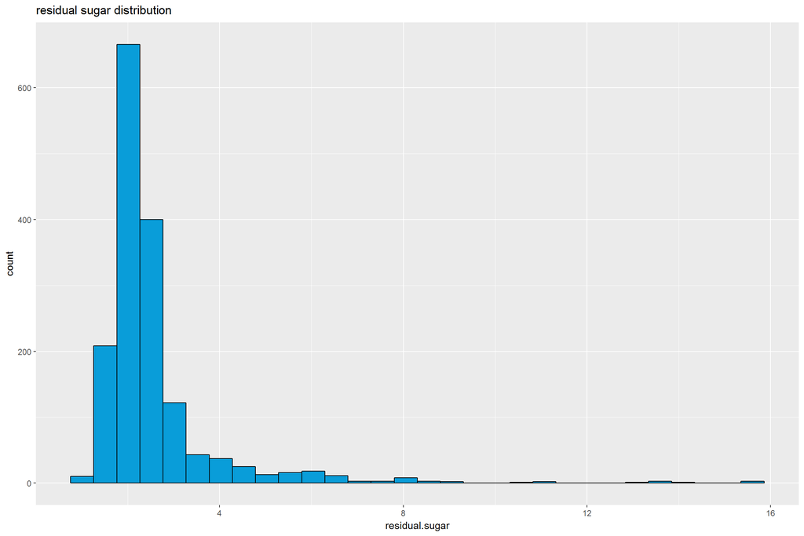

```
##    Min. 1st Qu.  Median    Mean 3rd Qu.    Max.
##   0.900   1.900   2.200   2.539   2.600  15.500
```

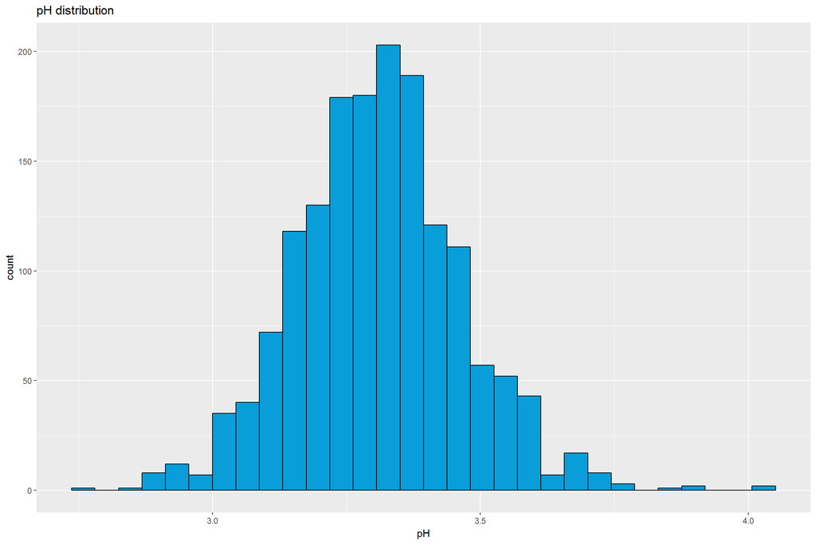

```
##    Min. 1st Qu.  Median    Mean 3rd Qu.    Max.
##   2.740   3.210   3.310   3.311   3.400   4.010
```

Most of the red wines have a pH of about 3.3.

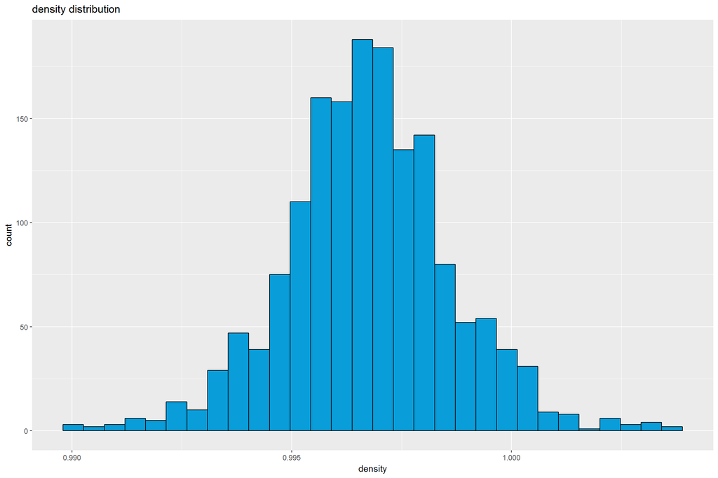

```
##    Min. 1st Qu.  Median    Mean 3rd Qu.    Max.
##  0.9901  0.9956  0.9968  0.9967  0.9978  1.0037
```

Most of the red wines have density of between 0.995 and 1.000. Next, I’m going to investigate the three variables about acid.

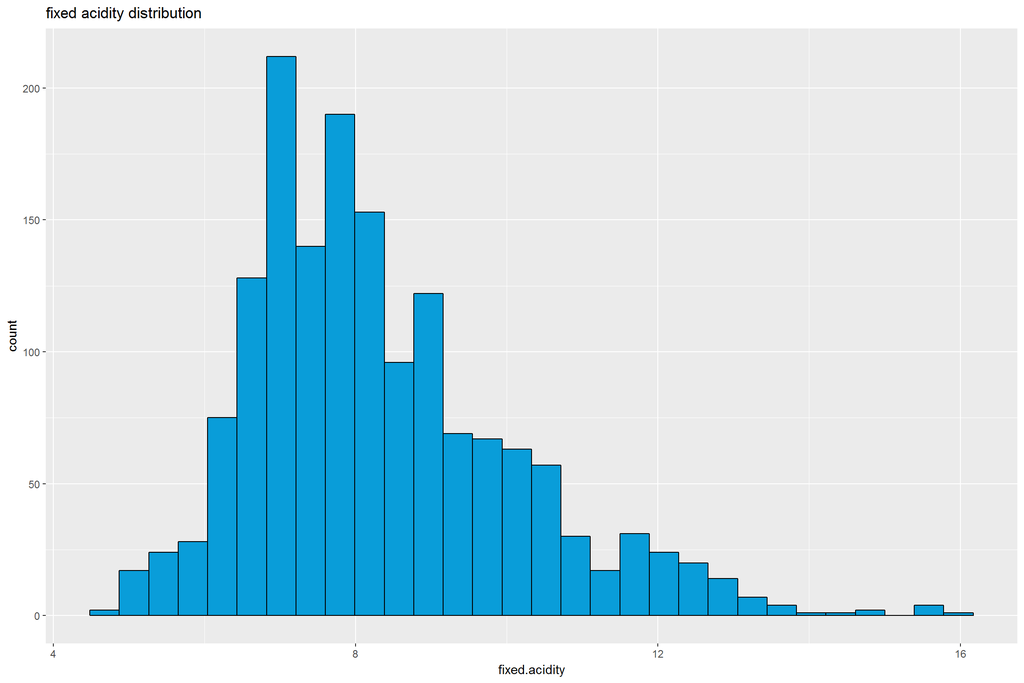

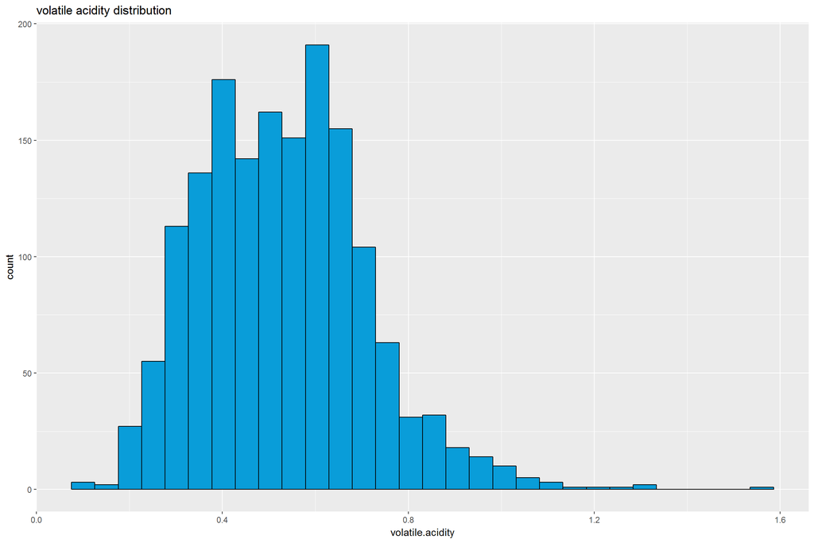

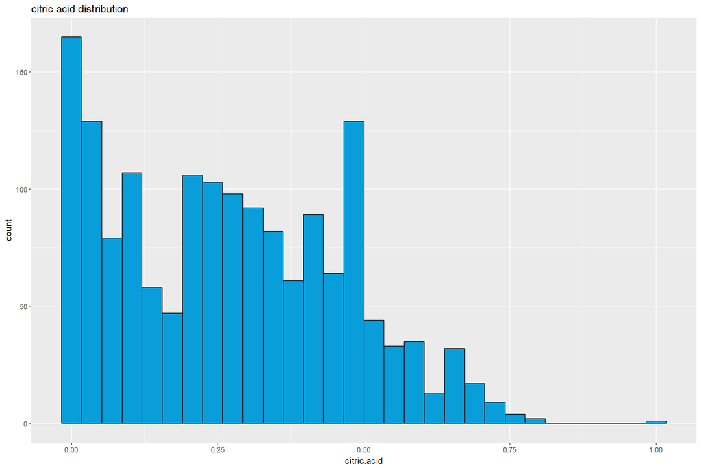

The fixed acidity of the majority of red wines are between 6 to 8. The volatile acidity peaks at 0.6, most of them falling between 0.2 and 0.8. Most of the citric.acid seems to a have a spread between 0 and 0.75.

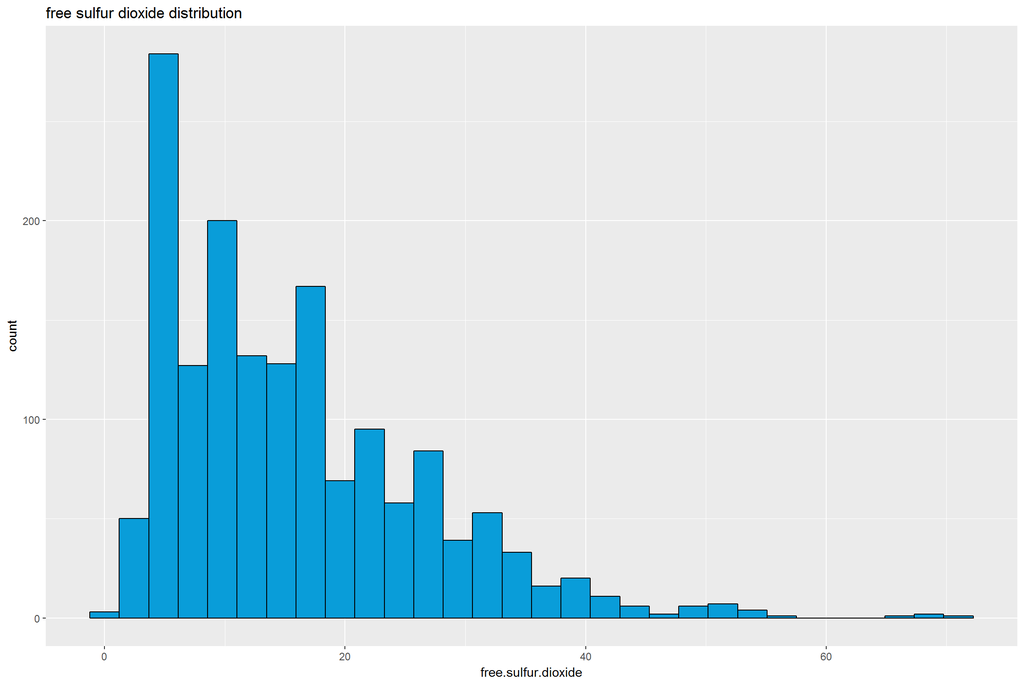

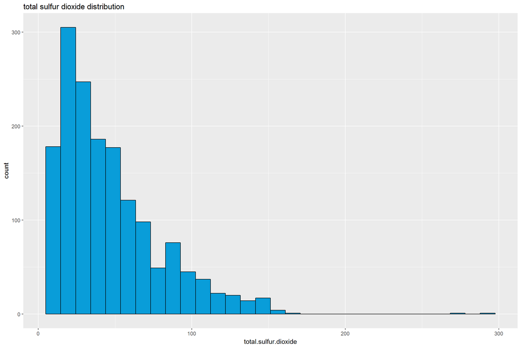

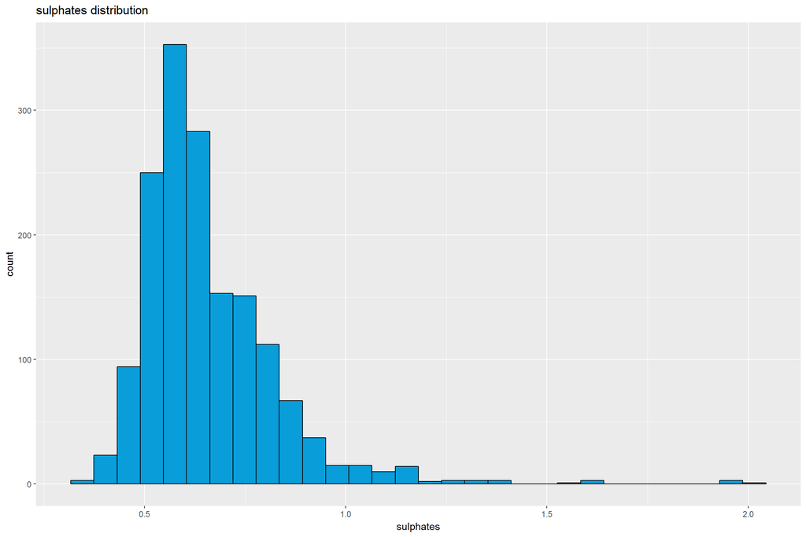

Most of the free sulfur dioxide seems to be between the 0-40. Most of the total sulfur dioxide seems to a have a spread between 0 and 150. Sulphates mostly fall between 0.5 and 1.0.

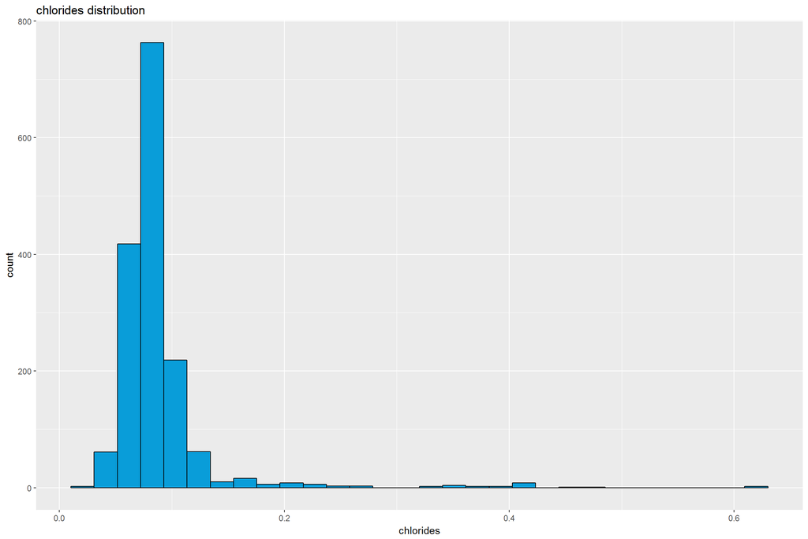

```
##    Min. 1st Qu.  Median    Mean 3rd Qu.    Max.
## 0.01200 0.07000 0.07900 0.08747 0.09000 0.61100
```

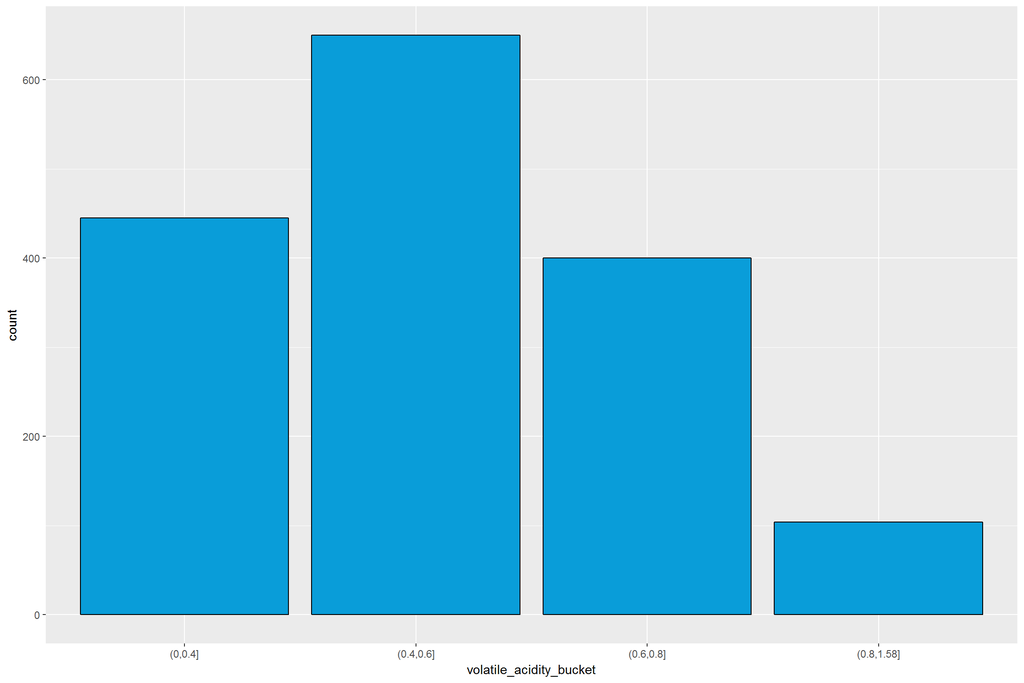

Most of the wines fall in the range of (0.4,0.6] in terms of volatile.acidity.

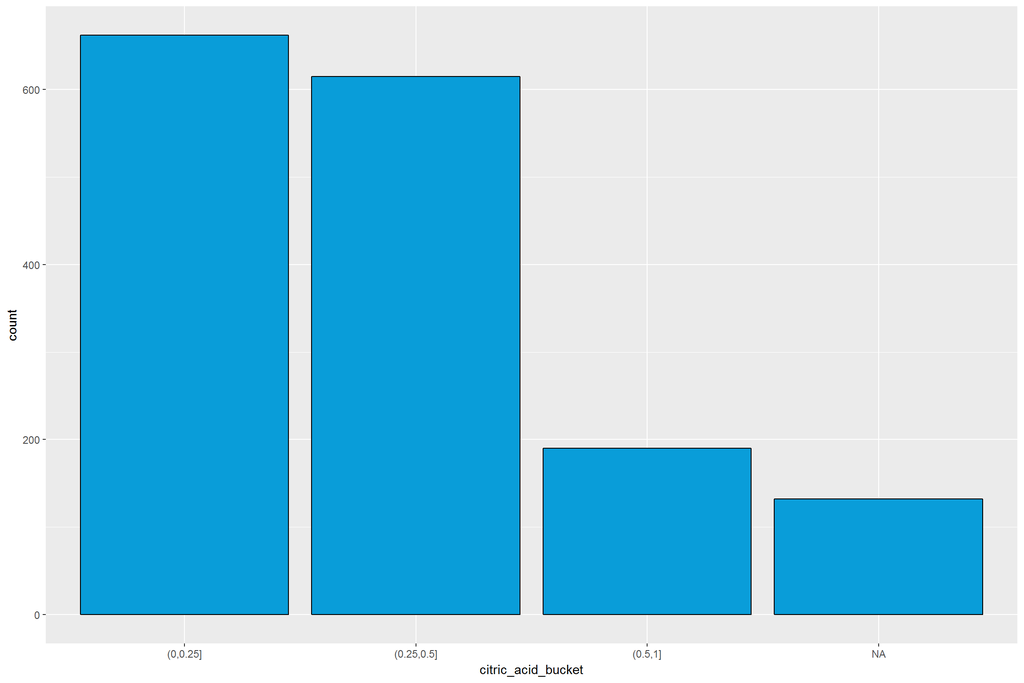

Most of the wines fall in the range of (0,0.25] in terms of citric.acid.

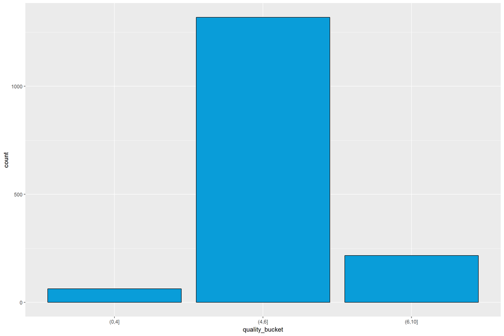

Most of the wines fall in the range of (4,6] in terms of quality.

# Univariate Analysis

### What is the structure of your dataset?

There are 1599 wines in the data set with 12 features(fixed.acidity, volatile.acidity, citric.acid, residual.sugar, chlorides, free.sulfur.dioxide, total.sulfur.dioxide, density, pH, sulphates, alcohol, quality)

Observations: 1. Most of the wines are just mediocre, and only a few of them could be considered of good quality. 2. Most of the features fall in a small range. For example, the data of density are between 0.995 and 1.000. 3. Red wines seem to be closely related to acid, SO2 and alcohol.

### What is/are the main feature(s) of interest in your dataset?

The main features in the dataset are acidity(both fixed and volatile) and acid and quality. I’d like to determine which features are best for predicting quality of wine and the relationships between those features. I think along with acidity (both fixed and volatile) and acid, alcohol and quantity of SO2 (free and total) might be used for predictive modeling to determine quality of wine.

### What other features in the dataset do you think will help support your investigation into your feature(s) of interest?

alcohol and quantity of SO2 (free and total)

### Did you create any new variables from existing variables in the dataset?

Yes. Quality_bucket is the variable added to the dataset which distributes the sample into 3 quality bins (0,4], (4,6] and (6,10]. As the description says that high amount of volatile.acidity can lead to an unpleasant taste and citric.acid can make the wine taste better when found in small amount, volatile_acidity_bucket,citric_acid_bucket and citric_have_or_not are also added to the dataset.

### Of the features you investigated, were there any unusual distributions? Did you perform any operations on the data to tidy, adjust, or change the form of the data? If so, why did you do this?

Most of the variables have outliers.

# Bivariate Plots Section

Lets see the correlation behaviour between the features.

```
##  [1] "X"                       "fixed.acidity"
##  [3] "volatile.acidity"        "citric.acid"
##  [5] "residual.sugar"          "chlorides"
##  [7] "free.sulfur.dioxide"     "total.sulfur.dioxide"
##  [9] "density"                 "pH"
## [11] "sulphates"               "alcohol"
## [13] "quality"                 "volatile_acidity_bucket"
## [15] "citric_acid_bucket"      "citric_have_or_not"
## [17] "quality_bucket"
```

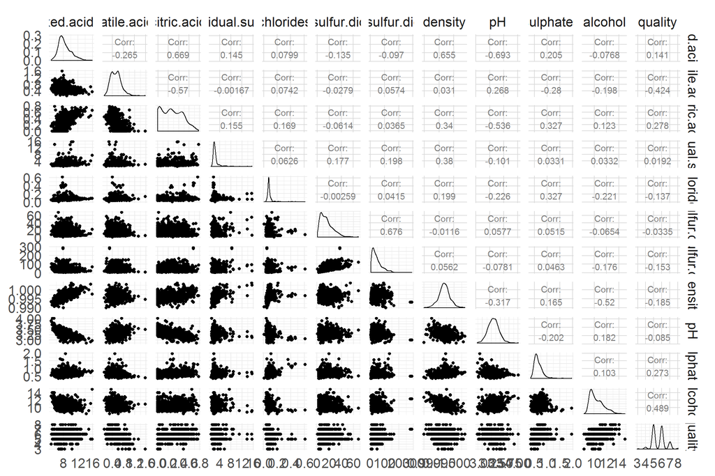

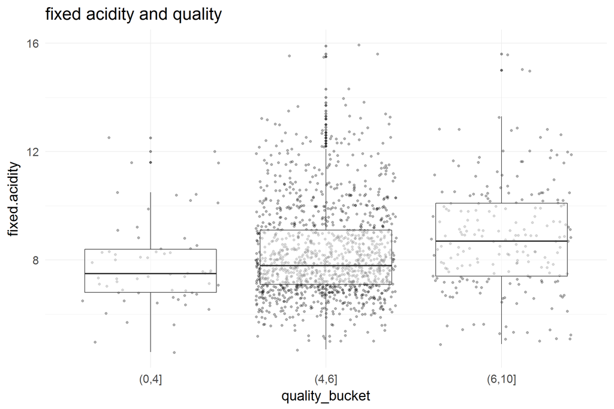

It seems fixed.acidity and quality are slightly correlated.

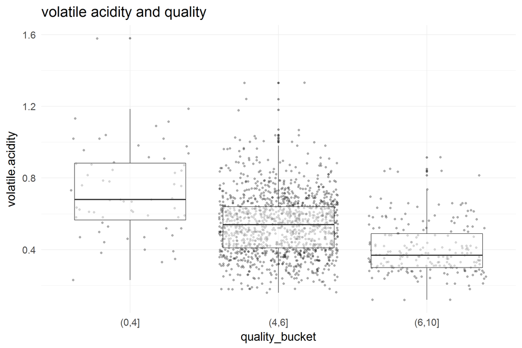

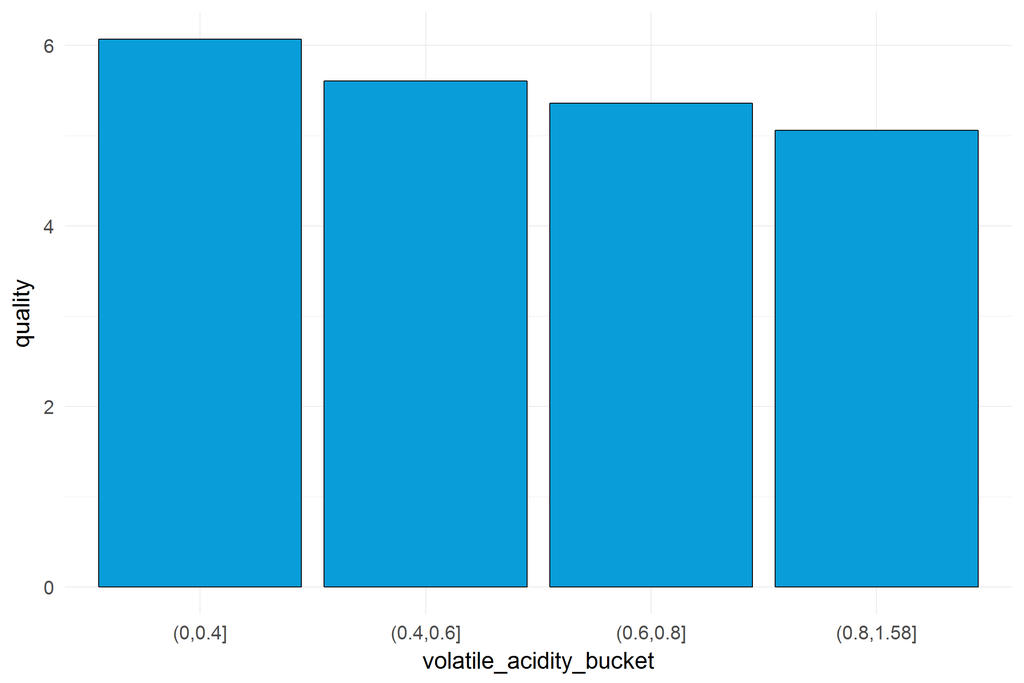

It’s clear that the quality of red wine will get worse as the amount of volatile.acidity increases. Let’s investigate another acid variable.

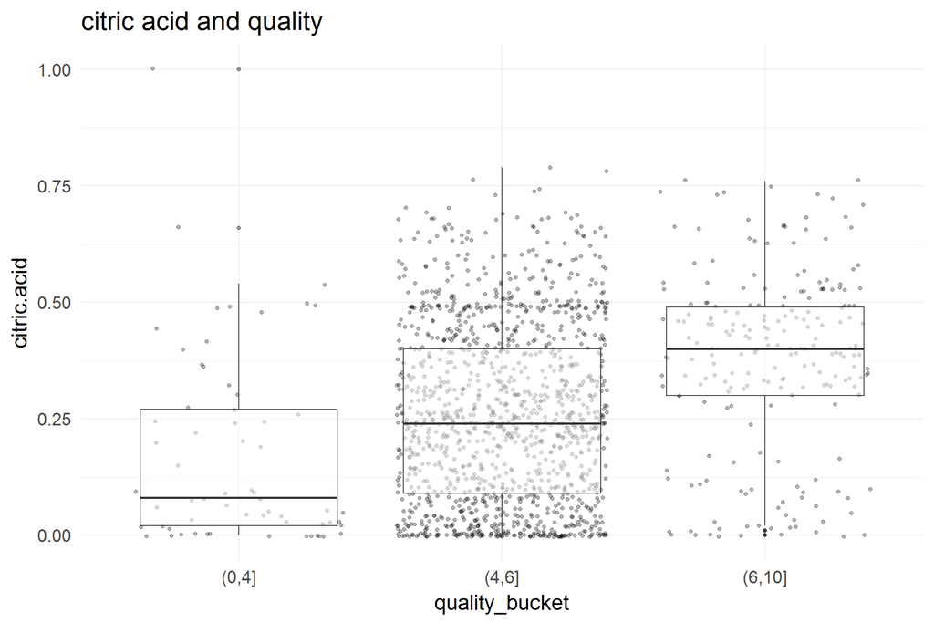

It’s hard to determine their relationship only according to this plot. I notice citric.acid can reach zero. Let’s see if the presence of citric.acid will affect the quality.

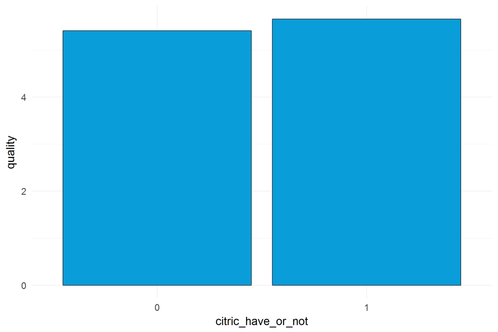

It seems wines with citric are slightly better. But I’d like to see with what amount of citric.acid the wines are the best.

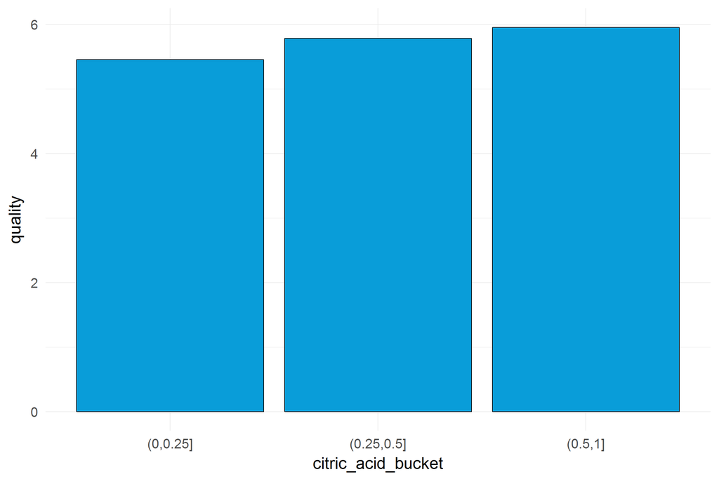

It seems that quality gets better as the amount of citric acid increases. But I notice in the matrix plot, citric.acid and fixed.acidity are closely related. Let’s investigate their relationship.

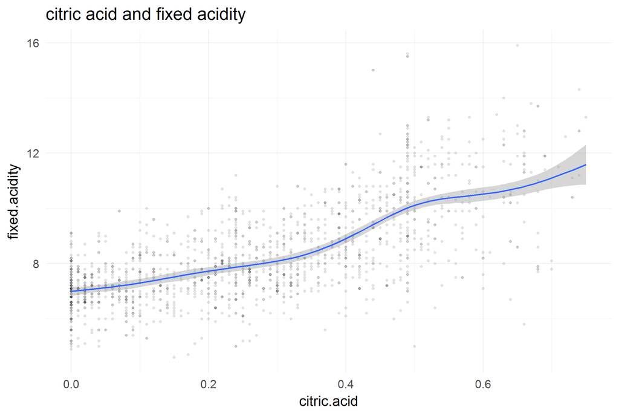

They seem to have positive correlation. I’m also curious about the correlation between fixed.acidity and volatile.acidity.

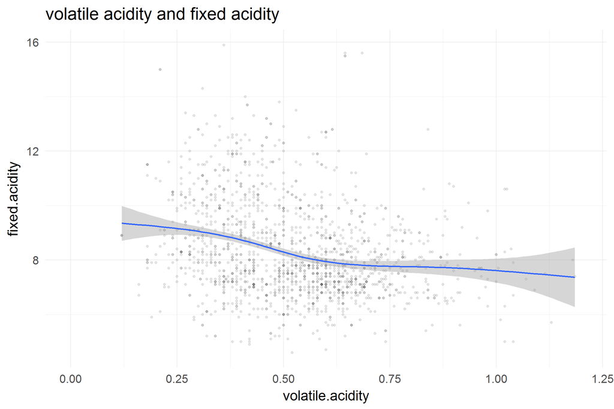

It seems they are slightly related. I also would like to see if volatile.acidity and citric.acid have any correlation.

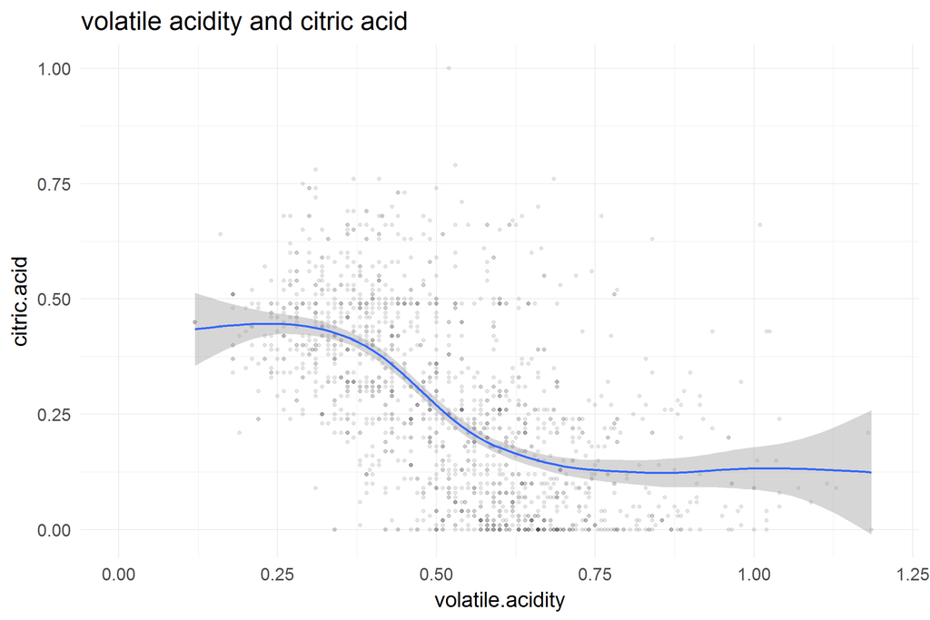

It’s clear that they are negatively correlated. As these three variables are all some kinds of acid, I suspect they are also related to pH.

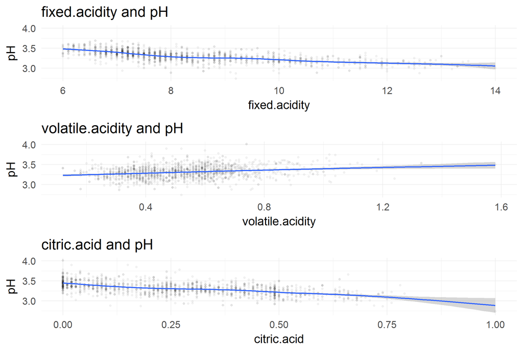

As the amounts of fixed.acidity and citric.acid increase, pH decreases, which is not unexpected. But pH will go up as the amount of volatile.acidity increases. So all thses three acid variables are closely related to pH and to quality, perhaps pH and quality are also closely related.

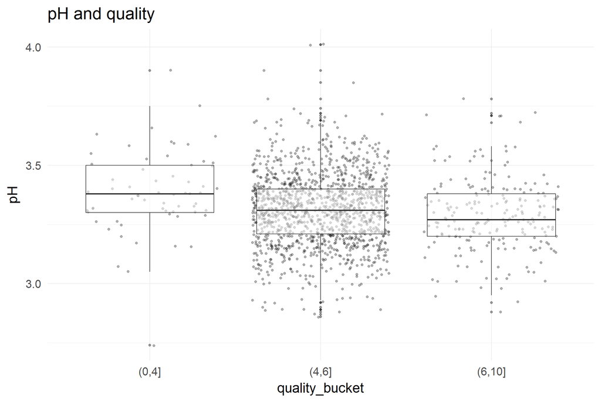

Though acid is related to quality and to pH, pH is not related to quality. This is surprising. I also suspect pH is related to variables about SO2. Let’s see if they are really correlated.

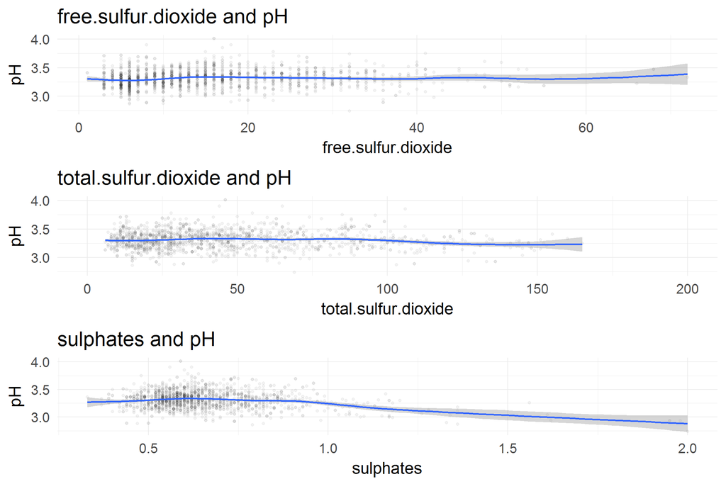

It seems SO2(both free and total) are not related to pH. As for sulphates, it is slightly negatively correlated with pH. I’m also curious about the relationship between the three SO2 variables.

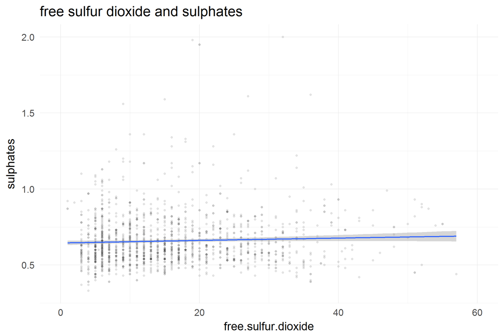

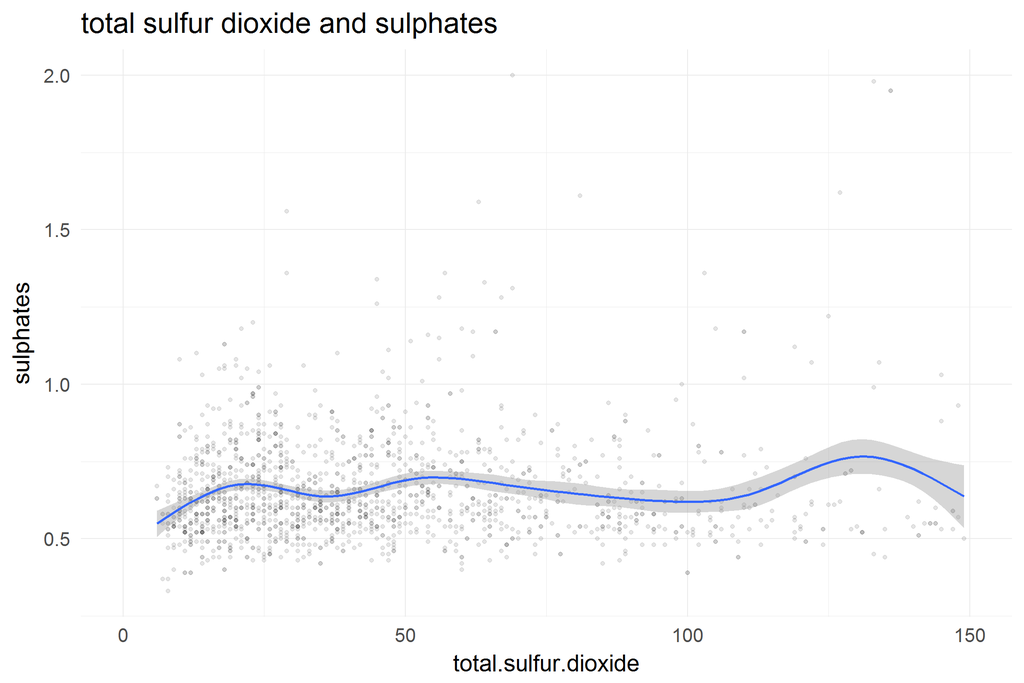

It seems SO2(both free and total) do not have close correlation with sulphates.

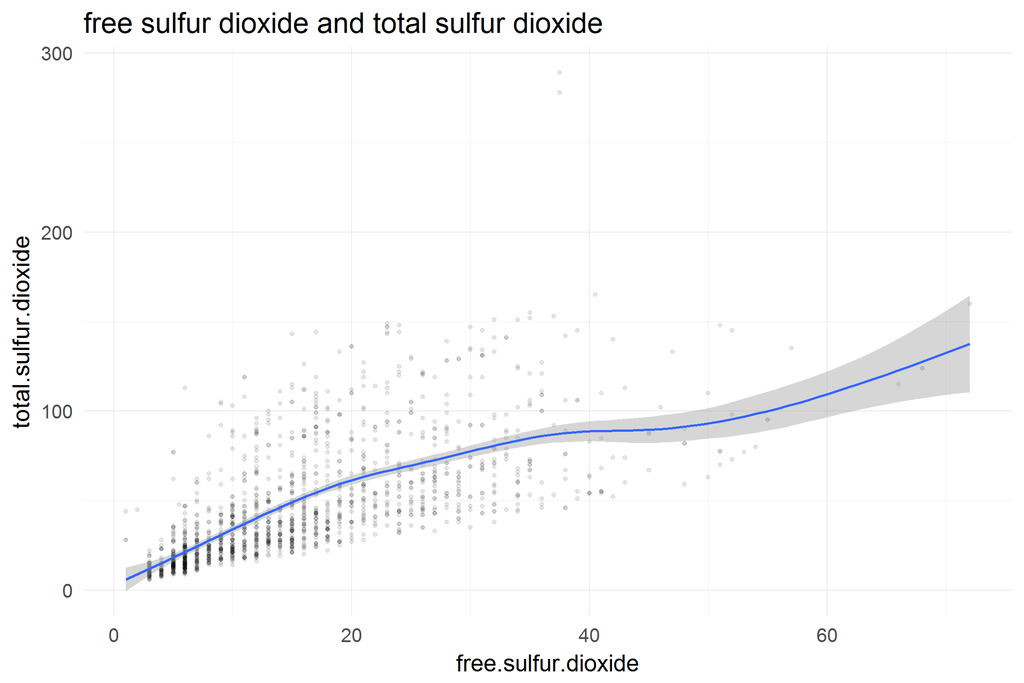

As the quantity of free sulfur dioxide goes up, the amount of total sulfur dioxide also increases. This is normal because total sulfur dioxide includes free sulfur dioxide.

Let’s now turn our eyes to the effect of alcohol.

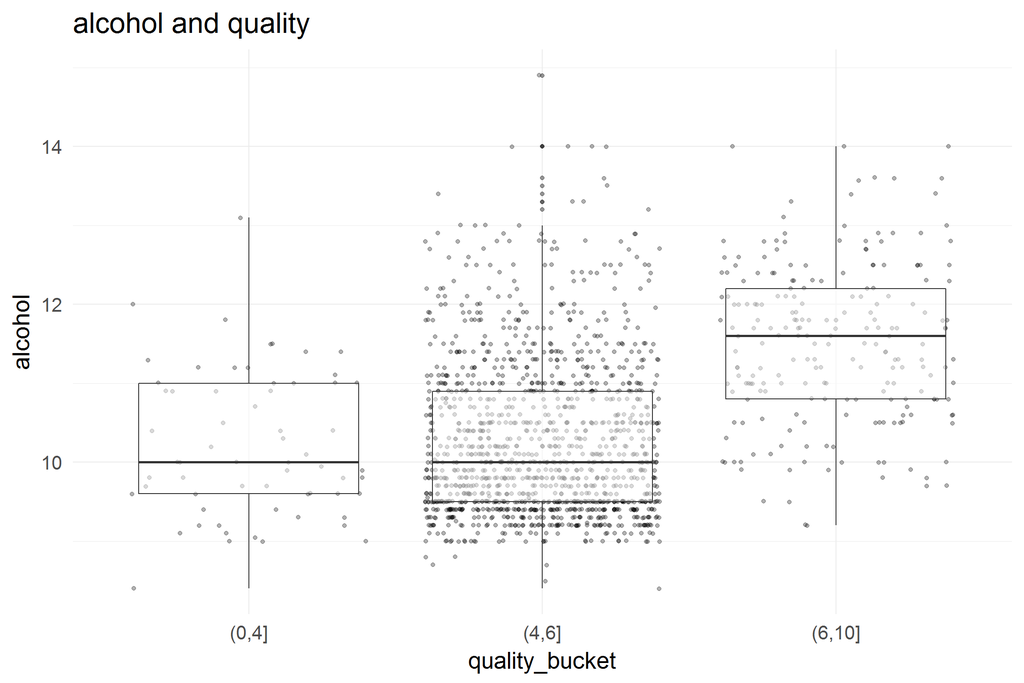

Like what I have expected, alcohol is strongly related to quality.